# ME613 - Análise de Regressão

## Transformações

## Transformações: relações não lineares

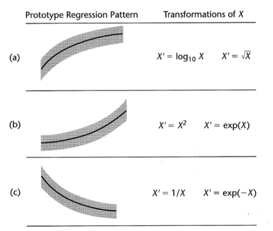

## Exemplo: Treinamento e Performance

\(X\): número de dias de treinamento recebido.

\(Y\): performance nas vendas.

| Parte 1 Days | Parte 1 Performance | Parte 2 Days | Parte 2 Performance |
| --- | --- | --- | --- |
| 0.5 | 42.5 | 1.5 | 99.6 |
| 0.5 | 50.6 | 2.0 | 105.3 |
| 1.0 | 68.5 | 2.0 | 111.8 |
| 1.0 | 80.7 | 2.5 | 112.3 |
| 1.5 | 89.0 | 2.5 | 125.7 |

## Exemplo: Treinamento e Performance

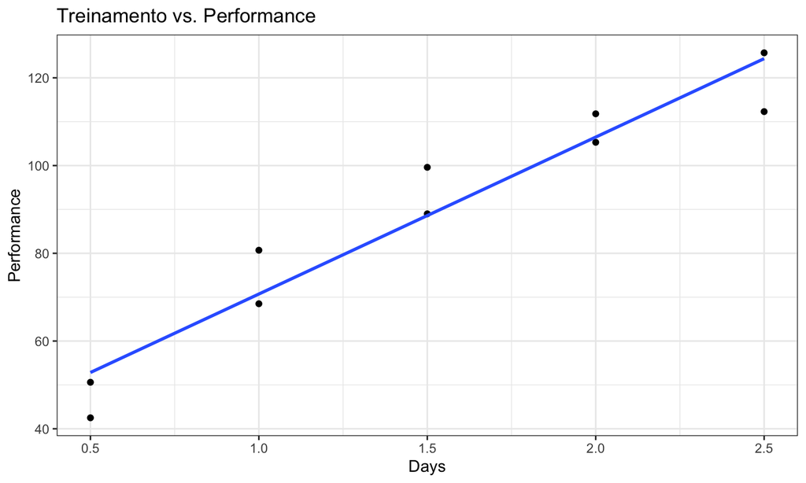

\[\hat{Y}=34.945 + 35.77X\]

## Exemplo: Treinamento e Performance

Gráfico de resíduos: \(e_i\) versus \(\hat{Y}_i\).

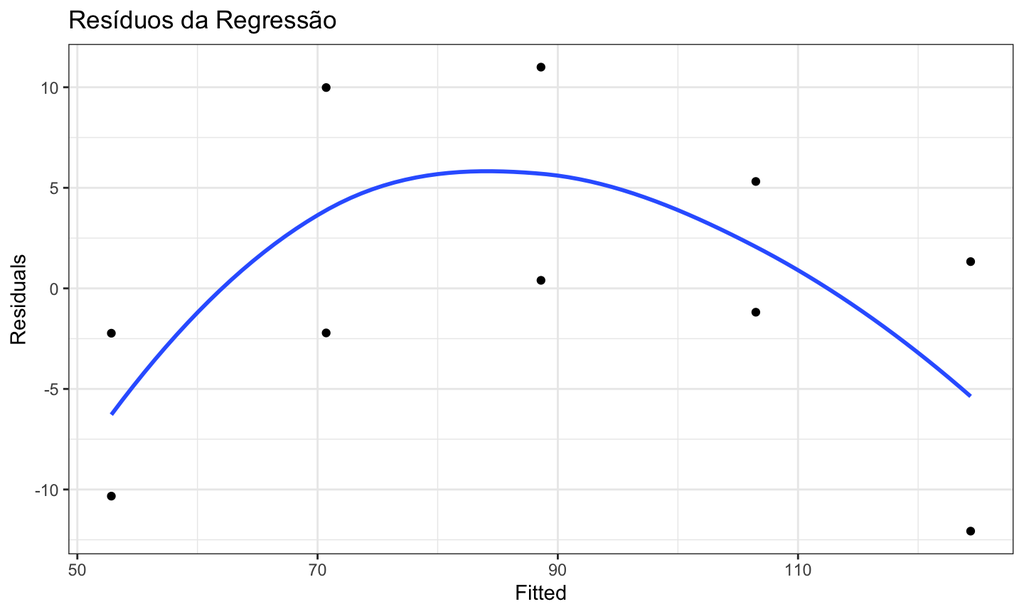

## Exemplo: Treinamento e Performance

Gráfico de resíduos: \(e_i\) versus \(X_i\).

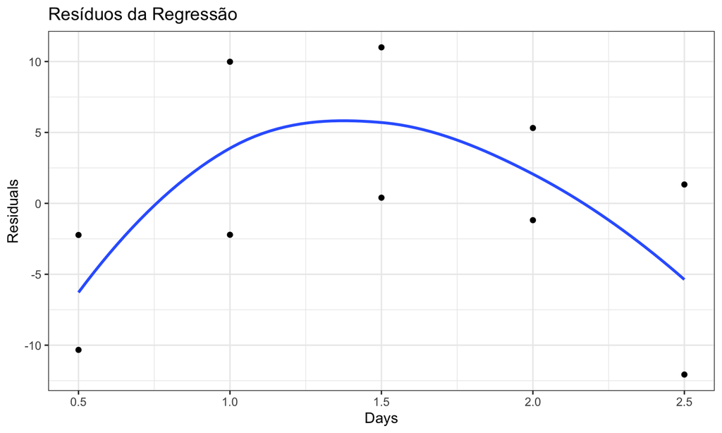

## Exemplo: Treinamento e Performance

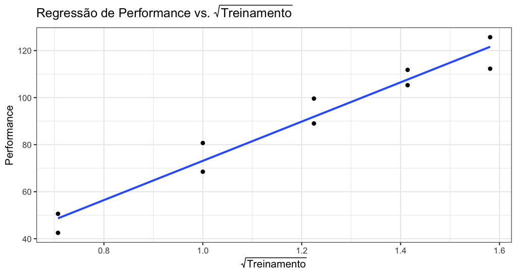

\[\hat{Y}=-10.33 + 83.45\sqrt{X}\]

## Exemplo: Treinamento e Performance

Gráfico de resíduos: \(e_i\) versus \(\hat{Y}_i\) usando \(\sqrt{\mbox{Treinamento}}\) no modelo.

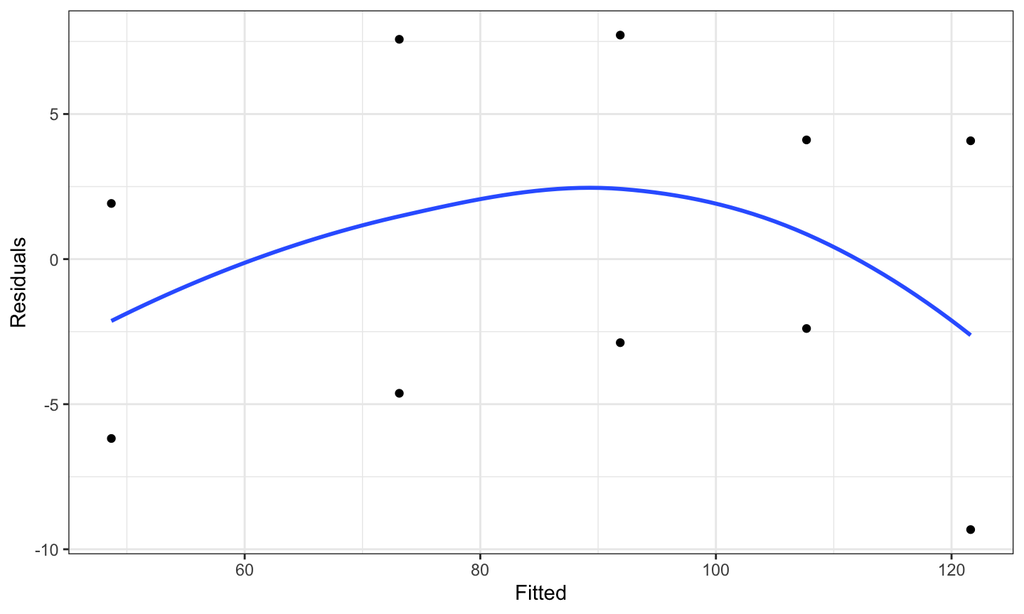

## Exemplo: Treinamento e Performance

Gráfico de resíduos: \(e_i\) versus \(X_i\) usando \(\sqrt{\mbox{Treinamento}}\) no modelo.

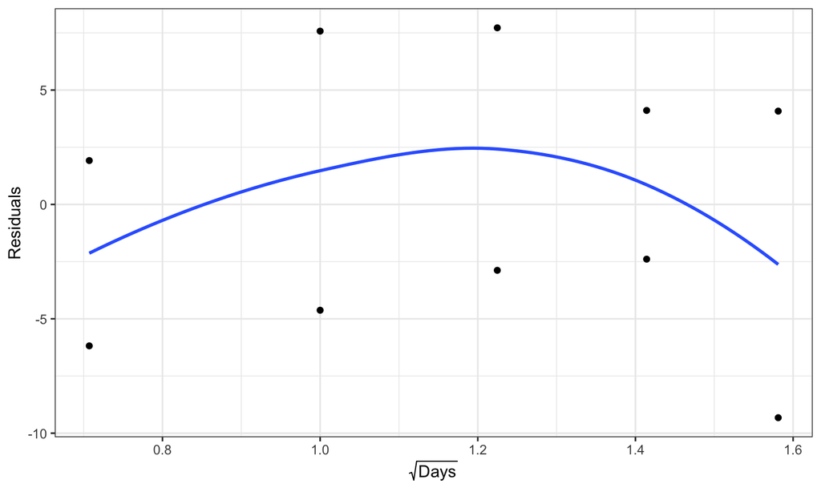

## Transformações: não normalidade e variância não constante

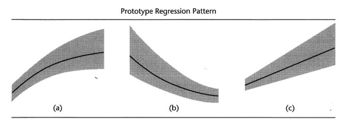

## Transformações: não normalidade e variância não constante

- Tentar encontrar transformação em \(Y\).
- Pode ser combinada com uma transformação também em \(X\).

## Exemplo: Idade e nível de poliamina

\(X\): Idade

\(Y\): nível de poliamina no plasma

| Parte 1 Idade | Parte 1 Poliamina | Parte 2 Idade | Parte 2 Poliamina | Parte 3 Idade | Parte 3 Poliamina | Parte 4 Idade | Parte 4 Poliamina |
| --- | --- | --- | --- | --- | --- | --- | --- |
| 0 | 13.44 | 1 | 10.28 | 2 | 8.88 | 4 | 5.10 |
| 0 | 12.84 | 1 | 8.96 | 3 | 7.94 | 4 | 5.67 |
| 0 | 11.91 | 1 | 8.59 | 3 | 6.01 | 4 | 5.75 |
| 0 | 20.09 | 2 | 9.83 | 3 | 5.14 | 4 | 6.23 |
| 0 | 15.60 | 2 | 9.00 | 3 | 6.90 | NA | NA |
| 1 | 10.11 | 2 | 8.65 | 3 | 6.77 | NA | NA |
| 1 | 11.38 | 2 | 7.85 | 4 | 4.86 | NA | NA |

## Exemplo: Idade e nível de poliamina

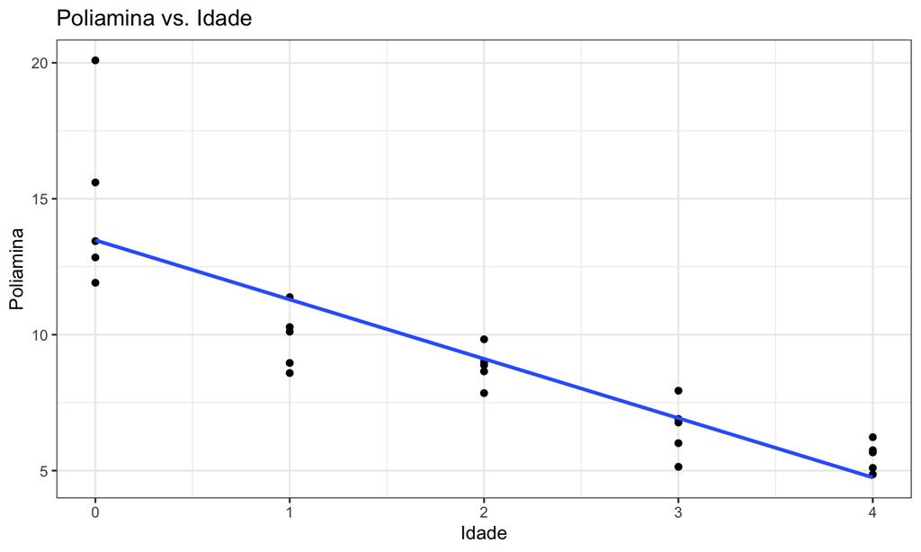

\[\hat{Y}=13.4752 - 2.182X\]

## Exemplo: Idade e nível de poliamina

Gráfico de resíduos: \(e_i\) versus \(\hat{Y}_i\).

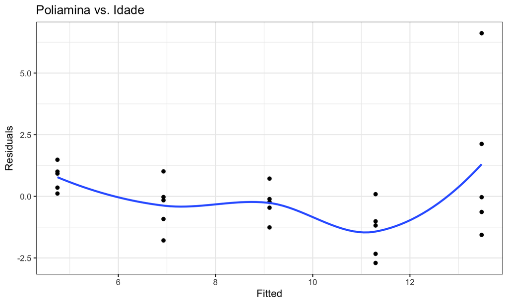

## Exemplo: Idade e nível de poliamina

Gráfico de resíduos: \(e_i\) versus \(X_i\).

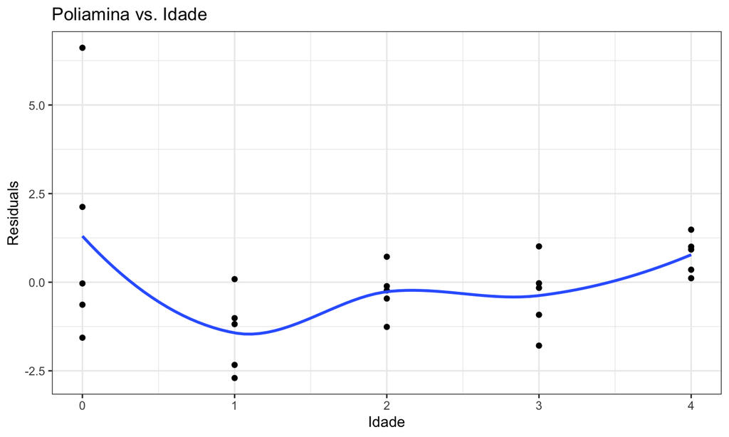

## Exemplo: Idade e nível de poliamina

\(Y'=\log_{10}Y\)

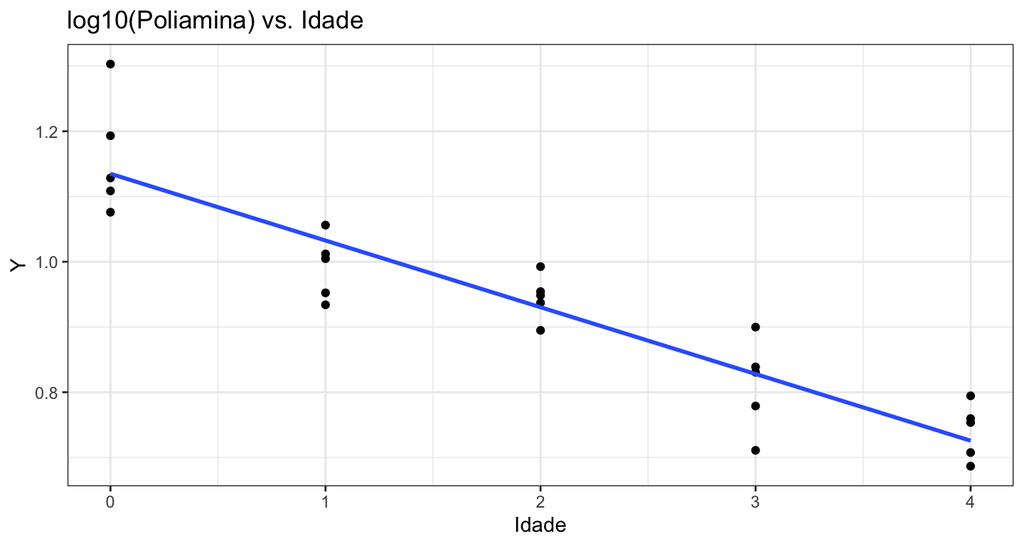

\[\hat{Y'}=1.13 - 0.1X\]

## Exemplo: Idade e nível de poliamina

Gráfico de resíduos: \(e_i\) versus \(\hat{Y'}_i\) usando \(Y'\) no modelo.

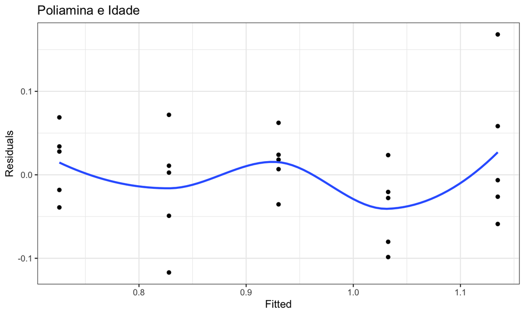

## Exemplo: Idade e nível de poliamina

Gráfico de resíduos: \(e_i\) versus \(X_i\).

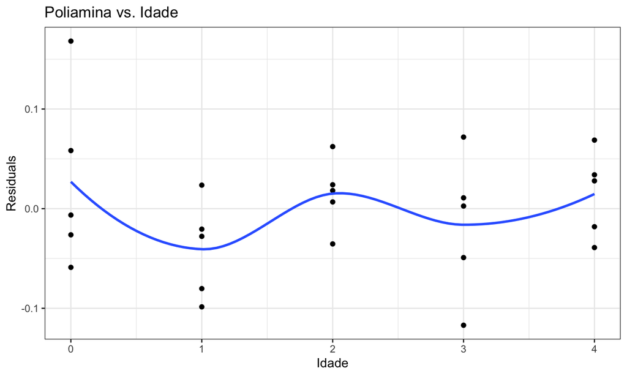

## Algumas transformações em \(Y\)

- \(\log_e(Y)\): para estabilizar a variância quando esta tende a crescer à medida que \(Y\) cresce.
- \(\sqrt{Y}\): estabilizar a variância quando esta é proporcional à média dos \(Y\)’s.
- \(\frac{1}{Y}\): estabilizar a variância, minimizando o efeito de valores muito altos de \(Y\).
- \(Y^2\): estabilizar a variância quando esta tende a decrescer com a média de \(Y\)’s.
- \(\arcsin{\sqrt{Y}}\): estabilizar a variância quando os dados são proporções.
- etc…

## Transformações de Box-Cox

- Muitas vezes é difícil determinar, através de gráficos, qual a melhor transformação a ser feita.
- O procedimento de [Box-Cox](http://www.jstor.org/stable/2984418) identifica automaticamente uma transformação:

\[Y'=Y^{\lambda}\]

em que \(\lambda\) é um parâmetro a ser determinado a partir dos dados.

- Modelo com dados transformados:

\[Y_i^{\lambda}=\beta_0+\beta_1X_i+\varepsilon_i\]

- O procedimento de Box-Cox utiliza o método de máxima verossimilhança para estimar \(\lambda\).

## Agradecimento

- Slides criados por Samara F Kiihl / IMECC / UNICAMP

## Leitura

- Applied Linear Statistical Models: 3.8-3.11.
- Weisberg - Applied Linear Regression: Capítulo 8.
- Faraway - [Linear Models with R](http://www.maths.bath.ac.uk/~jjf23/LMR/): Capítulo 9.

[figure not shown]